# MGSC 310 - Final Project

MGSC 310 Problem Set Template

Grace Montgomery and Ben Kahn

Here is the link to the dataset: https://www.kaggle.com/mterzolo/lego-sets

```r
lego_sets <- read.csv("lego_sets.csv")
lego_sets
```

| ages | list_price | num_reviews | piece_count | play_star_rating | prod_desc | prod_id | prod_long_desc | review_difficulty | set_name | star_rating | theme_name | val_star_rating | country |
| --- | --- | --- | --- | --- | --- | --- | --- | --- | --- | --- | --- | --- | --- |
| 6-12 | 29.9900 | 2 | 277 | 4.0 | Catapult into action and take back the eggs from the Piggy Trike! | 75823 | Use the staircase catapult to launch Red into the air and race after the piggy, who is speeding off in the Piggy Trike with the eggs. Help him take the eggs out of the trike's box in this hilarious se… | Average | Bird Island Egg Heist | 4.5 | Angry Birdsâ„¢ | 4.0 | US |
| 6-12 | 19.9900 | 2 | 168 | 4.0 | Launch a flying attack and rescue the eggs from the Piggy Plane! | 75822 | Pilot Pig has taken off from Bird Island with 4 eggs in his plane and is making his escape. Shoot Red into the sky using the catapult and on to the Piggy Plane. Battle with the piggy and take control … | Easy | Piggy Plane Attack | 5.0 | Angry Birdsâ„¢ | 4.0 | US |
| 6-12 | 12.9900 | 11 | 74 | 4.3 | Chase the piggy with lightning-fast Chuck and rescue the eggs! | 75821 | Pitch speedy bird Chuck against the Piggy Car. Chase the car to try and take back the eggs, but watch out for its ice cream shooter in this fun set, based on The Angry BirdsTM Movie. Includes 2 figure… | Easy | Piggy Car Escape | 4.3 | Angry Birdsâ„¢ | 4.1 | US |
| 12+ | 99.9900 | 23 | 1032 | 3.6 | Explore the architecture of the United States Capitol Building! | 21030 | Discover the architectural secrets of the iconic United States Capitol Building with this amazing LEGO® Architecture interpretation that focuses on the structure's neoclassical style facade, steps an… | Average | United States Capitol Building | 4.6 | Architecture | 4.3 | US |
| 12+ | 79.9900 | 14 | 744 | 3.2 | Recreate the Solomon R. Guggenheim Museum® with LEGO® Architecture! | 21035 | Discover the architectural secrets of Frank Lloyd Wrightâ\200\231s Solomon R. Guggenheim Museum®. This accurately detailed LEGO® model faithfully recreates the curves and distinctive lines that have… | Challenging | Solomon R. Guggenheim Museum® | 4.6 | Architecture | 4.1 | US |
| 12+ | 59.9900 | 7 | 597 | 3.7 | Celebrate Shanghai with this LEGO® Architecture Skyline set! | 21039 | Recreate Shanghai in China's blend of historical and modern architecture with this realistic 21039 LEGO® Architecture Skyline Collection model. This LEGO brick collectible toy features the city's ico… | Average | Shanghai | 4.9 | Architecture | 4.4 | US |
| 12+ | 59.9900 | 37 | 598 | 3.7 | Celebrate New York City with this LEGO® Architecture Skyline model! | 21028 | Celebrate the architectural diversity of New York City with this detailed LEGO® brick model. The LEGO Architecture Skyline Collection offers models suitable for display in the home and office, and ha… | Average | New York City | 4.2 | Architecture | 4.1 | US |
| 12+ | 49.9900 | 24 | 780 | 4.4 | Recreate Buckingham Palace with LEGO® Architecture! | 21029 | Build a LEGO® brick model of London's official royal residence. This magnificent model focuses on the palace's east wing with its famous balcony, forecourt and palace gates. A section of the Mall is … | Average | Buckingham Palace | 4.7 | Architecture | 4.3 | US |
| 12+ | 39.9900 | 23 | 468 | 3.6 | Celebrate London with this LEGO® Architecture Skyline model! | 21034 | Celebrate the architectural diversity of London with this detailed LEGO® brick model. The LEGO Architecture Skyline Collection offers models suitable for display in the home and office, and has been … | Average | London | 4.7 | Architecture | 4.1 | US |
| 12+ | 39.9900 | 11 | 444 | 3.6 | Celebrate Chicago with this LEGO® Architecture Skyline model! | 21033 | Recreate Chicagoâ\200\231s blend of historical and modern architecture with this realistic LEGO® brick model. The LEGO Architecture Skyline Collection offers models suitable for display in the home a… | Average | Chicago | 4.8 | Architecture | 4.5 | US |

[output cut: 990 more lines]

The outcome we are trying to predict is the list_price.

The variables we will use to predict it are listed below: ages, piece count, num_reviews, play_star_rating, review_difficulty, star_rating, val_star_rating, and country.

The motivation for our product is determining the list_price, because if we can determine what the price of a Lego set will be, we can figure out which types of sets will give us the most revenue, or from the perspective of the buyer, what types of sets give the best value. We also plan to use an ENet model to determine which variables are most influential to the list_price of the data set.

The methods we will be using to analyze our question:

1. Linear regression
2. Enet model to determine lasso vs. ridge
3. Depending on which one enet decides, use that

Group members: Ben Kahn and Grace Montgomery

```r
summary(lego_sets)
```

```
     ages             list_price        num_reviews      piece_count     play_star_rating  prod_desc
 Length:12261       Min.   :   2.272   Min.   :  1.00   Min.   :   1.0   Min.   :1.000    Length:12261
 Class :character   1st Qu.:  19.990   1st Qu.:  2.00   1st Qu.:  97.0   1st Qu.:4.000    Class :character
 Mode  :character   Median :  36.588   Median :  6.00   Median : 216.0   Median :4.500    Mode  :character
                    Mean   :  65.142   Mean   : 16.83   Mean   : 493.4   Mean   :4.338
                    3rd Qu.:  70.192   3rd Qu.: 13.00   3rd Qu.: 544.0   3rd Qu.:4.800
                    Max.   :1104.870   Max.   :367.00   Max.   :7541.0   Max.   :5.000
                                       NA's   :1620                      NA's   :1775
    prod_id        prod_long_desc     review_difficulty    set_name          star_rating     theme_name
 Min.   :    630   Length:12261       Length:12261       Length:12261       Min.   :1.800   Length:12261
 1st Qu.:  21034   Class :character   Class :character   Class :character   1st Qu.:4.300   Class :character
 Median :  42069   Mode  :character   Mode  :character   Mode  :character   Median :4.700   Mode  :character
 Mean   :  59837                                                            Mean   :4.514
 3rd Qu.:  70922                                                            3rd Qu.:5.000
 Max.   :2000431                                                            Max.   :5.000
                                                                            NA's   :1620
 val_star_rating   country
 Min.   :1.000   Length:12261
 1st Qu.:4.000   Class :character
 Median :4.300   Mode  :character
 Mean   :4.229
 3rd Qu.:4.700
 Max.   :5.000
 NA's   :1795
```

Example Cleaning code from Pset5

```r
library("tidyverse")
# options(scipen = 50)
# set.seed(1861)
# movies <- read.csv(here::here("datasets", "IMDB_movies.csv"))
# movies <- movies %>% filter(budget < 4e+08) %>% filter(content_rating !=
#     "", content_rating != "Not Rated", plot_keywords != "", !is.na(gross))
# movies <- movies %>% mutate(genre_main = unlist(map(strsplit(as.character(movies$genres),
#     "\\|"), 1)), plot_main = unlist(map(strsplit(as.character(movies$plot_keywords),
#     "\\|"), 1)), grossM = gross/1e+06, budgetM = budget/1e+06)
# movies <- movies %>% mutate(genre_main = fct_lump(genre_main,
#     7), plot_first = fct_lump(plot_main, 20), content_rating = fct_lump(content_rating,
#     4), country = fct_lump(country, 8), language = fct_lump(language,
#     4), cast_total_facebook_likes000s = cast_total_facebook_likes/1000) %>%
#     drop_na()
#
# top_director <- movies %>% group_by(director_name) %>% summarize(num_films = n()) %>%
#     top_frac(0.1) %>% mutate(top_director = 1) %>% select(-num_films)
#
# movies <- movies %>% left_join(top_director, by = "director_name") %>%
#     mutate(top_director = replace_na(top_director, 0)) %>% select(-c(director_name,
#     actor_2_name, gross, genres, actor_1_name, movie_title, actor_3_name,
#     plot_keywords, movie_imdb_link, budget, color, aspect_ratio,
#     plot_main, actor_3_facebook_likes, actor_2_facebook_likes,
#     color, num_critic_for_reviews, num_voted_users, num_user_for_reviews,
#     actor_2_facebook_likes))
#
# sapply(movies %>% select_if(is.factor), table)
#
# library("rsample")
#
# movies_split <- initial_split(movies, p = 0.75)
#
# movies_train <- training(movies_split)
# movies_test <- testing(movies_split)
```

Clean the dataset - need to factor: ages > but this has 31 factors, we may need to do some cleaning review difficulty - remove variables we are not going to use - create a training and testing set - TAKE OUT AGES OR FIX SINCE THERE ARE SO MANY FACTORS

```r
library(magrittr)
library('rsample')
library('tidyverse')

lego_clean <- lego_sets %>% select(-c(prod_long_desc,theme_name,prod_desc,set_name)) %>% mutate(
  ages = factor(ages), review_difficulty = factor(review_difficulty), country = factor(country)
) %>% drop_na()

lego_clean
```

| ages | list_price | num_reviews | piece_count | play_star_rating | prod_id | review_difficulty | star_rating | val_star_rating | country |
| --- | --- | --- | --- | --- | --- | --- | --- | --- | --- |
| 6-12 | 29.9900 | 2 | 277 | 4.0 | 75823 | Average | 4.5 | 4.0 | US |
| 6-12 | 19.9900 | 2 | 168 | 4.0 | 75822 | Easy | 5.0 | 4.0 | US |
| 6-12 | 12.9900 | 11 | 74 | 4.3 | 75821 | Easy | 4.3 | 4.1 | US |
| 12+ | 99.9900 | 23 | 1032 | 3.6 | 21030 | Average | 4.6 | 4.3 | US |
| 12+ | 79.9900 | 14 | 744 | 3.2 | 21035 | Challenging | 4.6 | 4.1 | US |
| 12+ | 59.9900 | 7 | 597 | 3.7 | 21039 | Average | 4.9 | 4.4 | US |
| 12+ | 59.9900 | 37 | 598 | 3.7 | 21028 | Average | 4.2 | 4.1 | US |
| 12+ | 49.9900 | 24 | 780 | 4.4 | 21029 | Average | 4.7 | 4.3 | US |
| 12+ | 39.9900 | 23 | 468 | 3.6 | 21034 | Average | 4.7 | 4.1 | US |
| 12+ | 39.9900 | 11 | 444 | 3.6 | 21033 | Average | 4.8 | 4.5 | US |

[output cut: 990 more lines]

```r
  # movies <- movies %>% mutate(genre_main = fct_lump(genre_main,
#     7), plot_first = fct_lump(plot_main, 20), content_rating = fct_lump(content_rating,
#     4), country = fct_lump(country, 8), language = fct_lump(language,
#     4), cast_total_facebook_likes000s = cast_total_facebook_likes/1000) %>%
#     drop_na()

# sum(is.na(lego_clean$num_reviews)) #this had some values
#
# sum(is.na(lego_clean$review_difficulty)) #when i looked, it looked like this was missing values but it says its not

lego_split <- initial_split(lego_clean, p = 0.75)

lego_train <- training(lego_split)
lego_test <- testing(lego_split)
```

```r
sum(is.na(lego_clean$piece_count))
```

```
[1] 0
```

```r
# lego_sets %<>% as.factor('review_difficulty' = review_difficulty)


mod1 <- lm(list_price ~ ages + piece_count + num_reviews + play_star_rating + review_difficulty + star_rating + val_star_rating + country,
           data = lego_train)

mod2 <- lm(list_price ~ piece_count,
           data = lego_train)
```

```r
#and other factor manipulation

# predictions
preds_train1 <- predict(mod1,
                     newdata = lego_train)
preds_train2 <- predict(mod2,
                        newdata = lego_train)
# preds_test <- predict(mod1,
#                      newdata = lego_test)
```

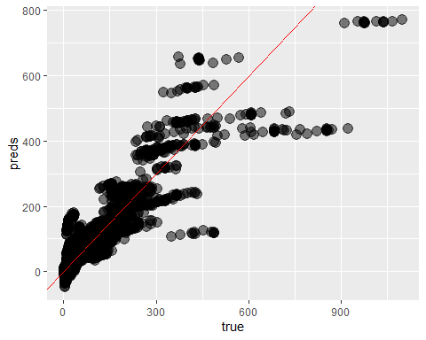

```r
# Dataframe and plot examples
results_train <- data.frame(
  preds = preds_train1,
  true = lego_train$list_price
)
ggplot(results_train,
       aes(x = true, y = preds)) +
  geom_point(alpha = 1/2, size = 4) +
  geom_abline(color = "red")
```

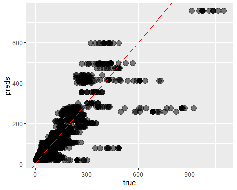

```r
# Dataframe and plot examples
results_train2 <- data.frame(
  preds = preds_train2,
  true = lego_train$list_price
)
ggplot(results_train2,
       aes(x = true, y = preds)) +
  geom_point(alpha = 1/2, size = 4) +
  geom_abline(color = "red")
```

```r
NA
NA
```

```r
library('ISLR')


glm_mod1 <- glm(list_price ~ ages + piece_count + num_reviews + play_star_rating + review_difficulty + star_rating +
                  val_star_rating + country,
           data = lego_train)
# Logit examples
# set family = binomial to set logistic function
# logit_fit1 <- glm(default ~ student,
#                   family = binomial,
#                   data = Default)
```

```r
preds_train_glm <- predict(glm_mod1,
                     newdata = lego_train)
```

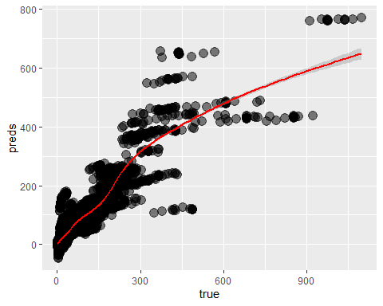

```r
# Dataframe and plot examples
results_train_glm <- data.frame(
  preds = preds_train_glm,
  true = lego_train$list_price
)
ggplot(results_train_glm,
       aes(x = true, y = preds)) +
  geom_point(alpha = 1/2, size = 4) +
  geom_smooth(color = "red")
```

```r
NA
NA
```

```r
library('yardstick')
library('ggplot2')
library('plotROC')

# p <- ggplot(results_train_glm,
#             aes(m = preds, d = true)) +
#   geom_roc(labelsize = 3.5,
#            cutoffs.at =
#              c(0.99,0.9,0.7,0.5,0.3,0.1,0)) +
#   theme_minimal(base_size = 16)
# print(p)
```

```r
summary(glm_mod1)
```

```
Call:
glm(formula = list_price ~ ages + piece_count + num_reviews +
    play_star_rating + review_difficulty + star_rating + val_star_rating +
    country, data = lego_train)

Deviance Residuals:
    Min       1Q   Median       3Q      Max
-286.73   -11.28    -0.68     9.55   486.21

Coefficients:
                                    Estimate Std. Error t value             Pr(>|t|)
(Intercept)                         60.04960   11.38749   5.273   0.0000001375967495 ***
ages10-16                          -13.03482   10.55749  -1.235             0.216997
ages10-21                           86.93345   11.33855   7.667   0.0000000000000197 ***
ages10+                              7.88468   10.03144   0.786             0.431893
ages11-16                          -42.43674   11.74015  -3.615             0.000303 ***
ages12-16                          -94.01598   12.81302  -7.338   0.0000000000002395 ***
ages12+                            -22.78700   10.26399  -2.220             0.026441 *
ages14+                            -12.06079   10.60965  -1.137             0.255667
ages16+                           -101.39132   10.61090  -9.555 < 0.0000000000000002 ***
ages1Â½-3                            7.08746   12.11617   0.585             0.558592
ages1Â½-5                            1.55692   11.80231   0.132             0.895054
ages2-5                             29.30464   10.15439   2.886             0.003914 **
ages4-7                             -0.30748   10.08880  -0.030             0.975687
ages4-99                           -18.32781   10.29709  -1.780             0.075131 .
ages4+                             -19.63059   14.30786  -1.372             0.170099
ages5-12                           -10.02890   10.03956  -0.999             0.317855
ages5-8                             19.05010   14.58014   1.307             0.191394
ages5+                             -10.02372   11.48417  -0.873             0.382783
ages6-12                            -8.31997    9.93075  -0.838             0.402170
ages6-14                           -13.63852   10.65900  -1.280             0.200748
ages6+                             113.27676   10.74664  10.541 < 0.0000000000000002 ***
ages7-12                            -7.08089   10.04715  -0.705             0.480977
ages7-14                            -8.55333    9.96203  -0.859             0.390592
ages8-12                           -12.25703   10.22158  -1.199             0.230513
ages8-14                            -9.74860    9.95208  -0.980             0.327337
ages8+                              -6.53487   10.37466  -0.630             0.528786
ages9-12                           -32.81501   12.52352  -2.620             0.008803 **
ages9-14                           -19.05718   10.00386  -1.905             0.056819 .
ages9-16                            -5.43792   11.03251  -0.493             0.622097
```

[output cut: 26 more lines]

```
countryNO                           10.64222    3.11777   3.413             0.000645 ***
countryNZ                            7.28650    3.08873   2.359             0.018346 *
countryPL                            5.52645    3.12500   1.768             0.077023 .
countryPT                            3.21607    3.11632   1.032             0.302099
countryUS                           -8.42499    2.82528  -2.982             0.002873 **
---
Signif. codes:  0 ‘***’ 0.001 ‘**’ 0.01 ‘*’ 0.05 ‘.’ 0.1 ‘ ’ 1

(Dispersion parameter for gaussian family taken to be 1668.629)

    Null deviance: 75481364  on 7849  degrees of freedom
Residual deviance: 12998623  on 7790  degrees of freedom
AIC: 80584

Number of Fisher Scoring iterations: 2
```

```r
table(lego_train$ages)
```

```
10-14 10-16 10-21   10+ 11-16 12-16   12+   14+   16+ 1Â½-3 1Â½-5   2-5   4-7  4-99    4+  5-12   5-8    5+
   18   111    57   590    44    27   214   160   320    34    41   300   442   209    18   582    14    53
 6-12  6-14    6+  7-12  7-14    7+  8-12  8-14    8+  9-12  9-14  9-16    9+
 1070   112   113   478  1034     0   248   795   161    30   487    71    17
```

```r
table(lego_train$country)
```

```
 AT  AU  BE  CA  CH  CZ  DE  DN  ES  FI  FR  GB  IE  IT  LU  NL  NO  NZ  PL  PT  US
344 364 382 525 355 345 352 372 342 357 353 390 377 351 345 371 344 357 341 345 538
```

```r
summary(mod1)
```

```
Call:
lm(formula = list_price ~ ages + piece_count + num_reviews +
    play_star_rating + review_difficulty + star_rating + val_star_rating +
    country, data = lego_train)

Residuals:
    Min      1Q  Median      3Q     Max
-286.73  -11.28   -0.68    9.55  486.21

Coefficients:
                                    Estimate Std. Error t value             Pr(>|t|)
(Intercept)                         60.04960   11.38749   5.273   0.0000001375967495 ***
ages10-16                          -13.03482   10.55749  -1.235             0.216997
ages10-21                           86.93345   11.33855   7.667   0.0000000000000197 ***
ages10+                              7.88468   10.03144   0.786             0.431893
ages11-16                          -42.43674   11.74015  -3.615             0.000303 ***
ages12-16                          -94.01598   12.81302  -7.338   0.0000000000002395 ***
ages12+                            -22.78700   10.26399  -2.220             0.026441 *
ages14+                            -12.06079   10.60965  -1.137             0.255667
ages16+                           -101.39132   10.61090  -9.555 < 0.0000000000000002 ***
ages1Â½-3                            7.08746   12.11617   0.585             0.558592
ages1Â½-5                            1.55692   11.80231   0.132             0.895054
ages2-5                             29.30464   10.15439   2.886             0.003914 **
ages4-7                             -0.30748   10.08880  -0.030             0.975687
ages4-99                           -18.32781   10.29709  -1.780             0.075131 .
ages4+                             -19.63059   14.30786  -1.372             0.170099
ages5-12                           -10.02890   10.03956  -0.999             0.317855
ages5-8                             19.05010   14.58014   1.307             0.191394
ages5+                             -10.02372   11.48417  -0.873             0.382783
ages6-12                            -8.31997    9.93075  -0.838             0.402170
ages6-14                           -13.63852   10.65900  -1.280             0.200748
ages6+                             113.27676   10.74664  10.541 < 0.0000000000000002 ***
ages7-12                            -7.08089   10.04715  -0.705             0.480977
ages7-14                            -8.55333    9.96203  -0.859             0.390592
ages8-12                           -12.25703   10.22158  -1.199             0.230513
ages8-14                            -9.74860    9.95208  -0.980             0.327337
ages8+                              -6.53487   10.37466  -0.630             0.528786
ages9-12                           -32.81501   12.52352  -2.620             0.008803 **
ages9-14                           -19.05718   10.00386  -1.905             0.056819 .
ages9-16                            -5.43792   11.03251  -0.493             0.622097
```

[output cut: 22 more lines]

```
countryIE                           -0.78846    3.04777  -0.259             0.795872
countryIT                            1.51544    3.10133   0.489             0.625108
countryLU                            3.06866    3.11561   0.985             0.324689
countryNL                            6.79770    3.05959   2.222             0.026327 *
countryNO                           10.64222    3.11777   3.413             0.000645 ***
countryNZ                            7.28650    3.08873   2.359             0.018346 *
countryPL                            5.52645    3.12500   1.768             0.077023 .
countryPT                            3.21607    3.11632   1.032             0.302099
countryUS                           -8.42499    2.82528  -2.982             0.002873 **
---
Signif. codes:  0 ‘***’ 0.001 ‘**’ 0.01 ‘*’ 0.05 ‘.’ 0.1 ‘ ’ 1

Residual standard error: 40.85 on 7790 degrees of freedom
Multiple R-squared:  0.8278,    Adjusted R-squared:  0.8265
F-statistic: 634.7 on 59 and 7790 DF,  p-value: < 0.00000000000000022
```

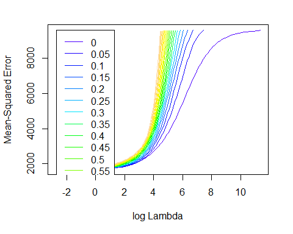

```r
library('tidyverse')
library('rsample')
library('glmnet')
library('glmnetUtils')
library('forcats')
library('broom') #this one is the one we added

# Lasso Model

# note cv.glmnet automatically performs k-fold cross-validation
# lasso_mod <- cv.glmnet(hwy ~ .,
#                        data = mpg_clean,
#                        # note alpha = 1 sets Lasso!
#                        alpha = 1)
enet_mod <- cva.glmnet(list_price ~ ages + piece_count + num_reviews + play_star_rating + review_difficulty + star_rating +
                  val_star_rating + country,
           data = lego_train,
                       alpha = seq(0,1, by = 0.05))

plot(enet_mod)
```

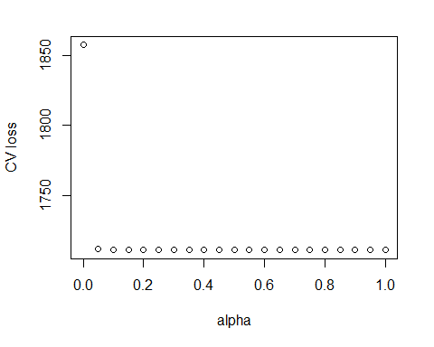

```r
minlossplot(enet_mod,
            cv.type = "min")
```

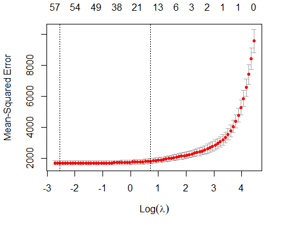

```r
lasso_mod <- cv.glmnet(list_price ~ ages + piece_count + num_reviews + play_star_rating + review_difficulty + star_rating +
                  val_star_rating + country,
                  data = lego_train,
                  alpha = 1)

plot(lasso_mod)
```

```r
NA
NA
```

```r
library(coefplot)
coefpath(lasso_mod)
```

[interactive chart not shown]

```r
NA
```

```r
print(lasso_mod$lambda.1se)
```

```
[1] 2.053866
```

```r
coef(lasso_mod,
     s = lasso_mod$lambda.min)
```

```
64 x 1 sparse Matrix of class "dgCMatrix"
                                            1
(Intercept)                        60.1722345
ages10-14                           7.7017472
ages10-16                          -2.5485474
ages10-21                          94.2989074
ages10+                            15.7642252
ages11-16                         -30.3768854
ages12-16                         -81.0407798
ages12+                           -12.5075288
ages14+                             .
ages16+                           -88.0262092
ages1Â½-3                          14.4895334
ages1Â½-5                           8.8405571
ages2-5                            37.3139298
ages4-7                             7.7054093
ages4-99                           -9.2678429
ages4+                             -7.6985281
ages5-12                           -1.1070592
ages5-8                            26.2112660
ages5+                             -0.7987863
ages6-12                            0.3200939
ages6-14                           -4.6004360
ages6+                            122.3658205
ages7-12                            1.4790912
ages7-14                            .
ages7+                              .
ages8-12                           -2.5837509
ages8-14                           -0.2585619
ages8+                              1.8720137
ages9-12                          -22.5679869
ages9-14                           -8.9503142
ages9-16                            2.8291689
ages9+                            -24.7682125
piece_count                         0.1079279
num_reviews                         0.1274471
play_star_rating                   11.5724937
review_difficulty                  -5.7996403
review_difficultyAverage            8.5678921
review_difficultyChallenging       10.1051336
```

[output cut: 11 more lines]

```
countryDE                           1.5697777
countryDN                         -13.3014922
countryES                           .
countryFI                           8.5568832
countryFR                           .
countryGB                          -2.2484607
countryIE                          -3.1564247
countryIT                          -0.8490233
countryLU                           .
countryNL                           3.7348915
countryNO                           7.5201855
countryNZ                           4.1907821
countryPL                           2.4645473
countryPT                           0.0760899
countryUS                         -10.8995959
```

```r
library('yardstick')
library('ggplot2')
library('plotROC')

# p <- ggplot(results_train_glm,
#             aes(m = preds, d = true)) +
#   geom_roc(labelsize = 3.5,
#            cutoffs.at =
#              c(0.99,0.9,0.7,0.5,0.3,0.1,0)) +
#   theme_minimal(base_size = 16)
# print(p)
```